# DS_Salaries_Explanatory_Analysis slides

## Data Science Salaries

### Introduction:

This analysis is done using the Data Science Salaries dataset which contains the salaries of some data science and other features that affects the salary.

The data used was collected from kaggle. [click here to open the data](https://www.kaggle.com/datasets/ruchi798/data-science-job-salaries)

The data contains 607 different data science records with 12 different features describing each Data Science role. The main purpose of this analysis is to stregthen my analytical thing skills by answering the following question below from the data.

#### Questions to answer:

- What is the most common Data Science Role?
- What is the most common payment currency?
- What is the salary trend for Data Science Roles?
- What is the average Salary based on Experience Level
- What is the trend for remote jobs? Is there an increase of decline for remote jobs?
- Which countries rank among the Top/Least 5 countries as regards to average Salary in USD?
- What branch of data science earns the most?

Check the **ReadMe** file attached to know more about the variables/features used in this analysis.

#### Question:

What is the most common Data Science Role?

In the this plot, there are so many Data Science Roles which i will be grouping for better analysis now and later. But from the above plot we can still see that **Data Science**, **Data Engineer** and **Data Analyst** are the most prominent roles.

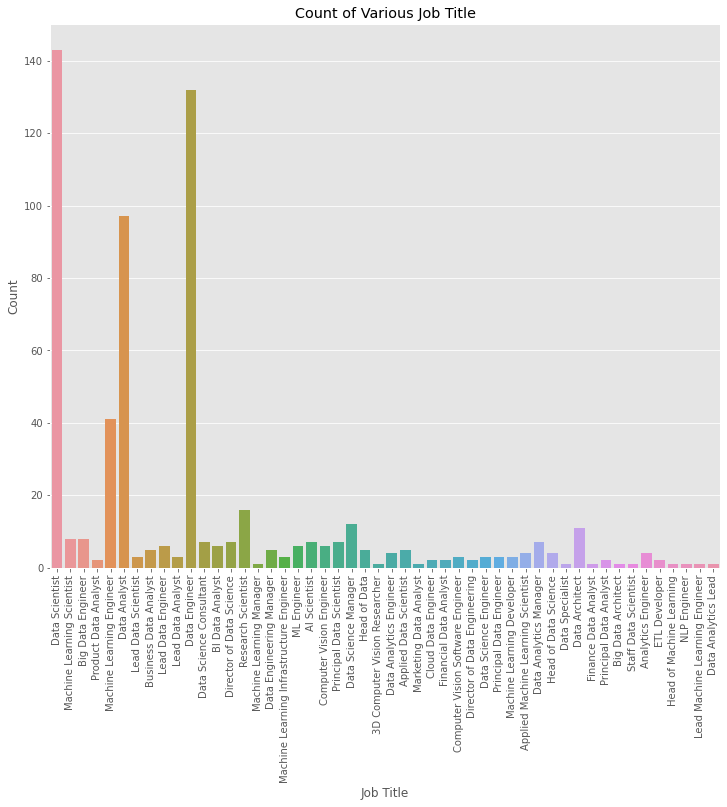

This plot further confirms our analysis above as Data Science and Data Engineer leads as the most common roles.

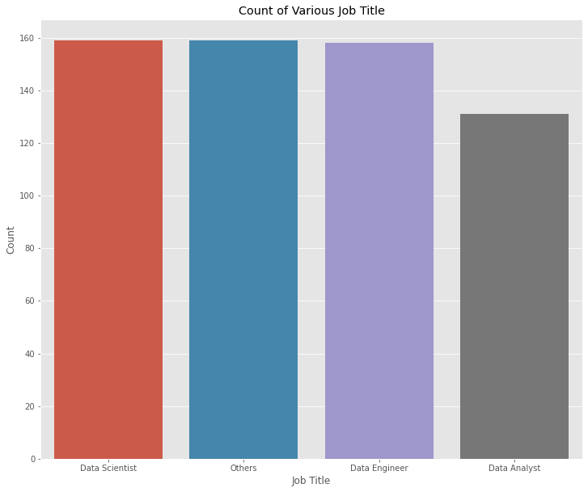

### Question

What is the most common payment currency?

We can see that the most used payment currency is the USD with almost 400 recordings of payments in USD. It is the most used currency in the world so it makes sense that it is the most used payment currency for **Data Science** roles

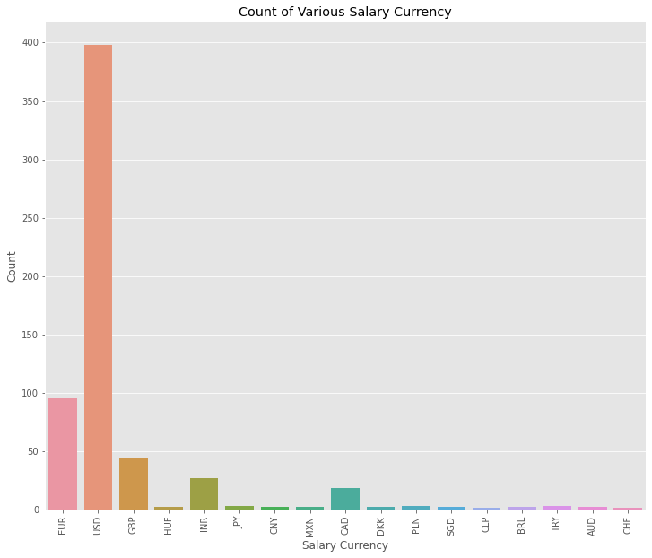

#### Question

What is the salary trend for Data Science Roles?

**Data Science** salaries has been on the up since year 2020. The increase in 2021 wasn't so great as compared to the increase in 2022. That means it is safe to say that there will be an increase in these salaries as time goes on.

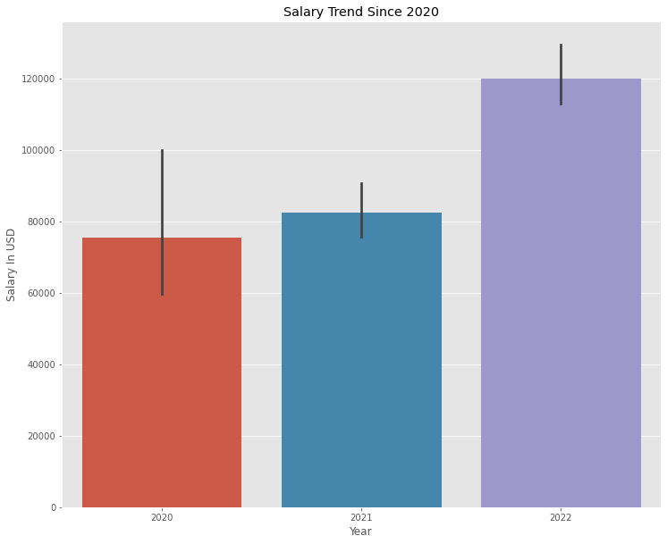

#### Question

What is the average Salary based on Experience Level?

The Executive/ Expert level earn over 171,000 USD on an average. It is the highest earn position(as expected). It is followed by the Senior level Data Scientist who earn about 135,000 USD on an average. The least is the entry level who earns about 56,000 USD on an average.

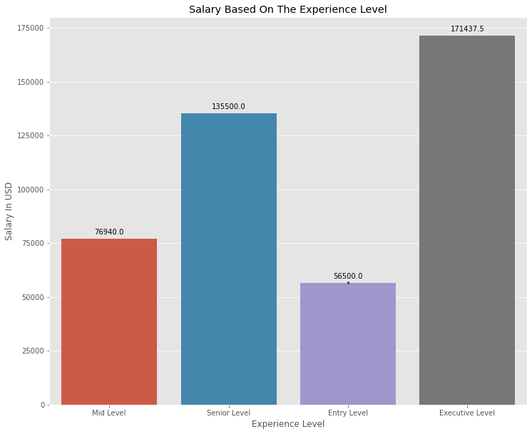

#### Question

What is the trend for remote jobs? Is there an increase of decline for remote jobs?

From the graph, we can see that there was an increase for remote jobs in 2021, but there is a drop in 2022. There are two likely causes.  
First, the record was collected for only the first part of the year which means that there will more remote jobs by the end of the year. Secondly, due to the rise in covid 19 in 2021, remote jobs was in demand due to restriction.

But by the end of the Year we can then confirm the rise in remote jobs or not.

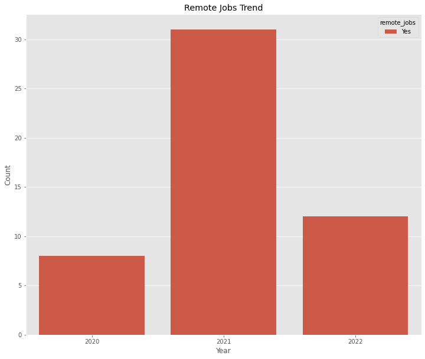

#### Question

WWhich countries rank among the Top 5 countries as regards to average Salary in USD??

Russia ranks the highest when it comes to highest salaries paid to Data Scientist on an average with over 157,000 USD followed by the US with 135,000 USD

[figure not shown]

#### Question

Which countries rank among the Least 5 countries as regards to average Salary in USD?

Vienam and Iran ranks the lowest paying countries on an average with 4,000 USD respectively

[figure not shown]

#### Question

What branch of data science earns the most?

**Data Engineer** and **Data Science** both earn over 115,000 USD respectively with small diffenrences in thousands. **Data Analyst** earns the least with salary of 96,000 USD

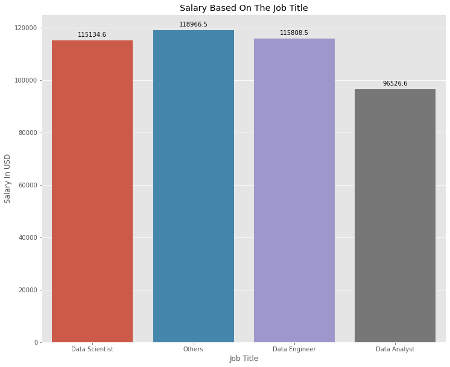

[output not shown]

[output cut: 110 more lines]

[output not shown]